# R Notebook

# Background

Using devices such as Jawbone Up, Nike FuelBand, and Fitbit it is now possible to collect a large amount of data about personal activity relatively inexpensively. These type of devices are part of the quantified self movement – a group of enthusiasts who take measurements about themselves regularly to improve their health, to find patterns in their behavior, or because they are tech geeks. One thing that people regularly do is quantify how much of a particular activity they do, but they rarely quantify how well they do it. In this project, your goal will be to use data from accelerometers on the belt, forearm, arm, and dumbell of 6 participants. They were asked to perform barbell lifts correctly and incorrectly in 5 different ways. More information is available from the website here: http://web.archive.org/web/20161224072740/http:/groupware.les.inf.puc-rio.br/har (see the section on the Weight Lifting Exercise Dataset).

Data

The training data for this project are available here:

https://d396qusza40orc.cloudfront.net/predmachlearn/pml-training.csv

The test data are available here:

https://d396qusza40orc.cloudfront.net/predmachlearn/pml-testing.csv

The data for this project come from this source: http://web.archive.org/web/20161224072740/http:/groupware.les.inf.puc-rio.br/har. If you use the document you create for this class for any purpose please cite them as they have been very generous in allowing their data to be used for this kind of assignment.

# Report

## setup

load libraries

```r
library(caret)
```

```r
library(tidyverse)
```

load data

```r
# download data
trainurl = "https://d396qusza40orc.cloudfront.net/predmachlearn/pml-training.csv"
testurl = "https://d396qusza40orc.cloudfront.net/predmachlearn/pml-testing.csv"
#download.file(trainurl, "pml-training.csv")
#download.file(testurl, "pml-testing.csv")
# load data
# exclude variables containing NA
# exclude first 7 variables (not used)
not_all_na <- function(x) {!all(is.na(x))} # select columns that dont have all values NA
not_any_na <- function(x) {!any(is.na(x))} # select columns that don't have any NA
training <-
  read_csv("pml-training.csv",na=c("NA","#DIV/0!", "")) %>%
  select_if(not_any_na) %>%
  select(-c(1:7))
testing <-
  read_csv("pml-testing.csv",na=c("NA","#DIV/0!", "")) %>%
  select_if(not_any_na) %>%
  select(-c(1:7))
# recode classe as numeric - now skipped (we dont save)
ALPHA2num <- function(x) {utf8ToInt(x) - utf8ToInt("A") + 1L}
ignore <- training %>%
  rowwise() %>%
  mutate(classe = ALPHA2num(classe))
```

split training into further training/testing for cross validation

```r
cv <- createDataPartition(y=training$classe, p=0.6, list = FALSE)
training_train <- training[cv, ]
training_test <- training[-cv, ]
```

Give us a quick summary of the training data

```r
library(skimr)
skim(training)
```

[output not shown]

[output not shown]

[output not shown]

[output cut: 46 more lines]

## modelling

Run a quick comparison of models Referenced from H2O library code example

```r
# Load library
library(h2o)
# start h2o cluster
invisible(h2o.init())
#convert variables to factors
training_train[,y] = as.factor(pull(training_train,y))
training_test[,y] = as.factor(pull(training_test,y))
# convert data as h2o type
train_h = as.h2o(training_train)
test_h = as.h2o(training_test)
# set label type
y = 'classe'
pred = setdiff(names(training_train), y)
#convert variables to factors
# Run AutoML for 20 base models
aml = h2o.automl(x = pred, y = y,
                  training_frame = train_h,
                  max_models = 20,
                  seed = 1,
                  max_runtime_secs = 20
                 )
```

Show leaderboard of models

```r
# AutoML Leaderboard
lb = aml@leaderboard
print(lb, n = nrow(lb))
```

|  | model_id | mean_per_class_error | logloss | rmse | mse |
| --- | --- | --- | --- | --- | --- |
| 1 | GBM_2_AutoML_2_20220703_202240 | 0.01086514 | 0.03863591 | 0.09264354 | 0.008582825 |
| 2 | GBM_3_AutoML_2_20220703_202240 | 0.01181071 | 0.04150688 | 0.09628754 | 0.009271291 |
| 3 | GBM_1_AutoML_2_20220703_202240 | 0.01351100 | 0.03227514 | 0.09290764 | 0.008631829 |
| 4 | DRF_1_AutoML_2_20220703_202240 | 0.01832705 | 0.15231994 | 0.18467547 | 0.034105028 |
| 5 | GLM_1_AutoML_2_20220703_202240 | 0.26887539 | 0.68682032 | 0.47114998 | 0.221982301 |

```
[5 rows x 5 columns]
```

From this we see that GBM_2 gives the best performance We display performance matrices and history of the model here

```r
m <- aml@leader
# create a confusion matrix
caret::confusionMatrix(training_test$classe, prediction$predict)
```

[output not shown]

```r
# close h2o connection
#h2o.shutdown(prompt = F)
m@parameters
```

```
$model_id
[1] "GBM_2_AutoML_2_20220703_202240"

$training_frame
[1] "AutoML_2_20220703_202240_training_training_train_sid_ade1_273"

$validation_frame
[1] "AutoML_2_20220703_202240_validation_training_train_sid_ade1_273"

$keep_cross_validation_models
[1] FALSE

$score_tree_interval
[1] 5

$ntrees
[1] 10000

$max_depth
[1] 7

$stopping_rounds
[1] 3

$stopping_metric
[1] "logloss"

$stopping_tolerance
[1] 0.009215122

$seed
[1] 4

$distribution
[1] "multinomial"

$sample_rate
[1] 0.8

$col_sample_rate
```

[output cut: 8 more lines]

```
$categorical_encoding
[1] "Enum"

$x
 [1] "roll_belt"            "pitch_belt"           "yaw_belt"             "total_accel_belt"     "gyros_belt_x"         "gyros_belt_y"         "gyros_belt_z"
 [8] "accel_belt_x"         "accel_belt_y"         "accel_belt_z"         "magnet_belt_x"        "magnet_belt_y"        "magnet_belt_z"        "roll_arm"
[15] "pitch_arm"            "yaw_arm"              "total_accel_arm"      "gyros_arm_x"          "gyros_arm_y"          "gyros_arm_z"          "accel_arm_x"
[22] "accel_arm_y"          "accel_arm_z"          "magnet_arm_x"         "magnet_arm_y"         "magnet_arm_z"         "roll_dumbbell"        "pitch_dumbbell"
[29] "yaw_dumbbell"         "total_accel_dumbbell" "gyros_dumbbell_x"     "gyros_dumbbell_y"     "gyros_dumbbell_z"     "accel_dumbbell_x"     "accel_dumbbell_y"
[36] "accel_dumbbell_z"     "magnet_dumbbell_x"    "magnet_dumbbell_y"    "magnet_dumbbell_z"    "roll_forearm"         "pitch_forearm"        "yaw_forearm"
[43] "total_accel_forearm"  "gyros_forearm_x"      "gyros_forearm_y"      "gyros_forearm_z"      "accel_forearm_x"      "accel_forearm_y"      "accel_forearm_z"
[50] "magnet_forearm_x"     "magnet_forearm_y"     "magnet_forearm_z"

$y
[1] "classe"
```

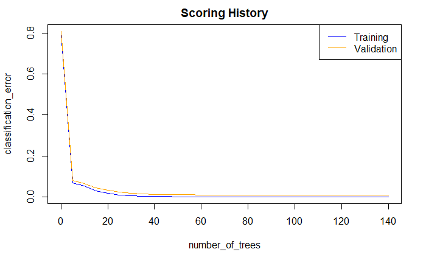

```r
plot(m)
```

And finally the prediction on the test dataset (now validation dataset)

```r
validation_h = as.h2o(testing)
prediction = h2o.predict(aml@leader, validation_h) %>%
                         as.data.frame()
```

```r
# converted to h2o frame

prediction
```

| predict | A | B | C | D | E |
| --- | --- | --- | --- | --- | --- |
| B | 5.876795e-03 | 8.853072e-01 | 1.068642e-01 | 5.120398e-04 | 1.439777e-03 |
| A | 9.997455e-01 | 2.177900e-04 | 2.225265e-05 | 4.943333e-06 | 9.553789e-06 |
| B | 7.791393e-03 | 9.688698e-01 | 1.868828e-02 | 1.351823e-03 | 3.298711e-03 |
| A | 9.997204e-01 | 7.985877e-06 | 1.012960e-04 | 1.664220e-04 | 3.927235e-06 |
| A | 9.998675e-01 | 6.249663e-05 | 6.080677e-05 | 1.357940e-06 | 7.812599e-06 |
| E | 1.923637e-06 | 5.791374e-05 | 2.889833e-04 | 6.002039e-06 | 9.996452e-01 |
| D | 4.588773e-05 | 2.468543e-04 | 2.135429e-03 | 9.974382e-01 | 1.336762e-04 |
| B | 3.388855e-04 | 9.966069e-01 | 7.522652e-04 | 1.595089e-03 | 7.068835e-04 |
| A | 9.999760e-01 | 1.535018e-05 | 3.016274e-06 | 3.024034e-06 | 2.614116e-06 |
| A | 9.999519e-01 | 3.776395e-05 | 5.717074e-06 | 2.461197e-06 | 2.140006e-06 |

[output cut: 10 more lines]

```r
pull(prediction,predict)
```

```
 [1] B A B A A E D B A A B C B A E E A B B B
Levels: A B C D E
```